# Homework4

21400022 YounhongKo

2020 5 23

### Read CSV File

```r
PRSA <- read.csv(file = 'PRSA_data.csv')
```

### Import Library

```r
library(rpart)
library(rpart.plot)
library(ROCR)
library(class)
library(caret)
```

### Declare Functions

```r
minmax_norm <- function(x) {
  (x-min(x))/(max(x)-min(x))
}

f1_measure <- function(precision, recall) {
  m <- 2 * precision * recall / (precision + recall)
}

calAUC <- function(predCol, targetCol){
  perf <- performance(prediction(predCol, targetCol), 'auc')
  as.numeric(perf@y.values)
}

getACC <- function(i) {
  prsa_test_pred <-
    knn(train = prsa_train_norm, test = prsa_test_norm, cl = prsa_train_label,
        k = i)
  mean(prsa_test_label == prsa_test_pred)
}

getPrec <- function(i) {
  prsa_test_pred <-
    knn(train = prsa_train_norm, test = prsa_test_norm, cl = prsa_train_label,
        k = i)
  cmat <- table(prsa_test_label, prsa_test_pred)
  cmat[2,2] / sum(cmat[,2])
}

getRecall <- function(i) {
  prsa_test_pred <-
    knn(train = prsa_train_norm, test = prsa_test_norm, cl = prsa_train_label,
        k = i)

  cmat <- table(prsa_test_label, prsa_test_pred)
  cmat[2,2] / sum(cmat[2,])
}

getF1 <- function(i) {
  prsa_test_pred <-
    knn(train = prsa_train_norm, test = prsa_test_norm, cl = prsa_train_label,
        k = i)
  cmat <- table(prsa_test_label, prsa_test_pred)
  prsa_knn_prec <- cmat[2,2] / sum(cmat[,2])
  prsa_knn_rec <- cmat[2,2] / sum(cmat[2,])
  f1_measure(prsa_knn_prec, prsa_knn_rec)
}

getAUC <- function(i) {
  prsa_test_pred <-
    knn(train = prsa_train_norm, test = prsa_test_norm, cl = prsa_train_label,
        k = i, prob = TRUE)

  prsa_test_pred_prob <-
    ifelse(prsa_test_pred==TRUE, attributes(prsa_test_pred)$prob,
           1 - attributes(prsa_test_pred)$prob)
  calAUC(prsa_test_pred_prob, prsa_test_label)
}

get_high_thres_recall <- function(i) {
  threshold <- i
  prsa_test_pred_prob <-
    ifelse(prsa_test_pred==TRUE, attributes(prsa_test_pred)$prob,
           1 - attributes(prsa_test_pred)$prob)
  prsa_test_pred_new <- ifelse(
    prsa_test_pred_prob > threshold, "T", "F")
  cmat <- table(prsa_test_label, prsa_test_pred_new)
  cmat[2,2] / sum(cmat[2,])
}
```

# Decision Tree

### 1

```r
PRSA <- na.omit(PRSA)
PRSA$bad_air <- ifelse(PRSA$pm2.5 > 75, T, F)

prsa.train <- subset(PRSA, year <= 2013)
prsa.test <- subset(PRSA, year > 2013)
```

### 2

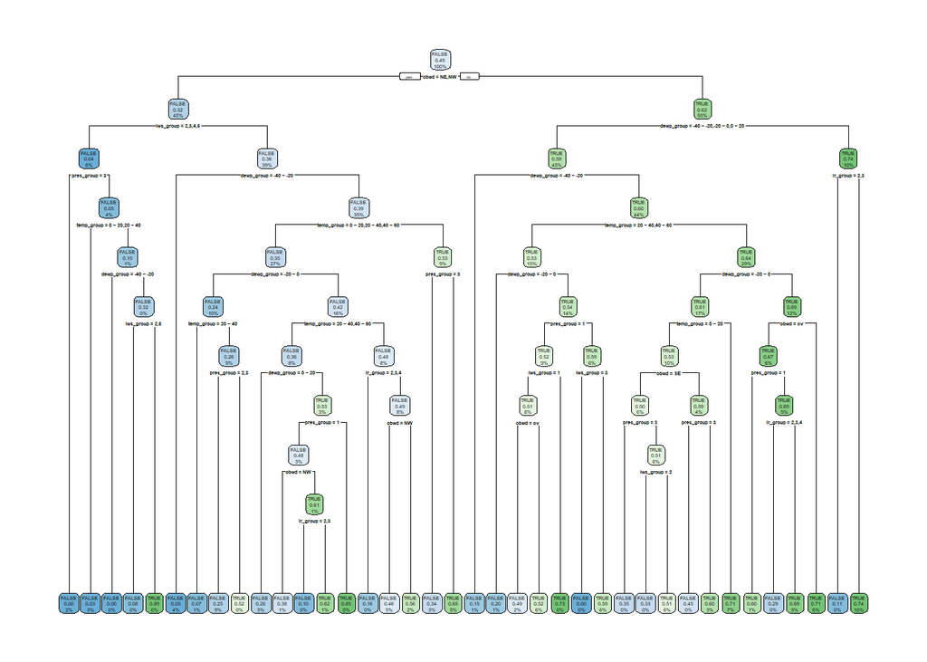

```r
prsa.train$dewp_group <- cut(prsa.train$DEWP, breaks = c(-40, -20, 0, 20, 40),
                             labels = c('-40 ~ -20', '-20 ~ 0', '0 ~ 20', '20 ~ 40'),
                             right = F)
prsa.train$temp_group <- cut(prsa.train$TEMP, breaks = c(-20, 0, 20, 40, 60),
                             labels = c('-20 ~ 0', '0 ~ 20', '20 ~ 40', '40 ~ 60'),
                             right = F)
prsa.train$pres_group <- cut(prsa.train$PRES, breaks = c(990, 1010, 1030, 1050),
                             labels = c('1', '2', '3'),
                             right = F)
prsa.train$is <- as.numeric(prsa.train$Is)
prsa.train$is_group <- cut(prsa.train$is, breaks = c(0, 10.0, 20.0, 30.0),
                           labels = c('1', '2', '3'),
                           right = F)
prsa.train$iws_group <- cut(prsa.train$Iws, breaks = c(0, 100, 200, 300, 400, 500, 600),
                            labels = c('1', '2', '3', '4', '5', '5'),
                            right = F)
prsa.train$ir_group <- cut(prsa.train$Ir, breaks = c(0, 10, 20, 30, 40),
                           labels = c('1', '2', '3', '4'),
                           right = F)
prsa_model <- rpart(bad_air ~
        dewp_group+temp_group+pres_group+is_group+iws_group+ir_group+cbwd,
        data = prsa.train, method = "class",
                    control = rpart.control(cp = 0))
rpart.plot(prsa_model)
```

```r
prsa_model
```

```
## n= 33096
##
## node), split, n, loss, yval, (yprob)
##       * denotes terminal node
##
##    1) root 33096 16085 FALSE (0.51398961 0.48601039)
##      2) cbwd=NE,NW 14821  4737 FALSE (0.68038594 0.31961406)
##        4) iws_group=2,3,4,5 1999    72 FALSE (0.96398199 0.03601801)
##          8) pres_group=3 656     1 FALSE (0.99847561 0.00152439) *
##          9) pres_group=1,2 1343    71 FALSE (0.94713328 0.05286672)
##           18) temp_group=0 ~ 20,20 ~ 40 1088    32 FALSE (0.97058824 0.02941176) *
##           19) temp_group=-20 ~ 0 255    39 FALSE (0.84705882 0.15294118)
##             38) dewp_group=-40 ~ -20 134     0 FALSE (1.00000000 0.00000000) *
##             39) dewp_group=-20 ~ 0 121    39 FALSE (0.67768595 0.32231405)
##               78) iws_group=2,5 85     7 FALSE (0.91764706 0.08235294) *
##               79) iws_group=3,4 36     4 TRUE (0.11111111 0.88888889) *
##        5) iws_group=1 12822  4665 FALSE (0.63617220 0.36382780)
##         10) dewp_group=-40 ~ -20 1160    59 FALSE (0.94913793 0.05086207) *
##         11) dewp_group=-20 ~ 0,0 ~ 20,20 ~ 40 11662  4606 FALSE (0.60504202 0.39495798)
##           22) temp_group=0 ~ 20,20 ~ 40,40 ~ 60 8834  3094 FALSE (0.64976228 0.35023772)
##             44) dewp_group=-20 ~ 0 3415   824 FALSE (0.75871157 0.24128843)
##               88) temp_group=20 ~ 40 359    26 FALSE (0.92757660 0.07242340) *
##               89) temp_group=0 ~ 20 3056   798 FALSE (0.73887435 0.26112565)
##                178) pres_group=2,3 2928   732 FALSE (0.75000000 0.25000000) *
##                179) pres_group=1 128    62 TRUE (0.48437500 0.51562500) *
##             45) dewp_group=0 ~ 20,20 ~ 40 5419  2270 FALSE (0.58110352 0.41889648)
##               90) temp_group=20 ~ 40,40 ~ 60 2777   998 FALSE (0.64061937 0.35938063)
##                180) dewp_group=0 ~ 20 1781   470 FALSE (0.73610331 0.26389669) *
##                181) dewp_group=20 ~ 40 996   468 TRUE (0.46987952 0.53012048)
##                  362) pres_group=1 865   416 FALSE (0.51907514 0.48092486)
##                    724) cbwd=NW 493   189 FALSE (0.61663286 0.38336714) *
##                    725) cbwd=NE 372   145 TRUE (0.38978495 0.61021505)
##                     1450) ir_group=2,3 10     1 FALSE (0.90000000 0.10000000) *
##                     1451) ir_group=1 362   136 TRUE (0.37569061 0.62430939) *
##                  363) pres_group=2 131    19 TRUE (0.14503817 0.85496183) *
##               91) temp_group=0 ~ 20 2642  1272 FALSE (0.51854656 0.48145344)
##                182) ir_group=2,3,4 75    12 FALSE (0.84000000 0.16000000) *
##                183) ir_group=1 2567  1260 FALSE (0.50915466 0.49084534)
##                  366) cbwd=NW 1749   800 FALSE (0.54259577 0.45740423) *
##                  367) cbwd=NE 818   358 TRUE (0.43765281 0.56234719) *
```

[output cut: 25 more lines]

```
##                    867) iws_group=1 1933   944 TRUE (0.48836006 0.51163994) *
##                217) cbwd=cv 1228   506 TRUE (0.41205212 0.58794788)
##                  434) pres_group=3 110    49 FALSE (0.55454545 0.44545455) *
##                  435) pres_group=1,2 1118   445 TRUE (0.39803220 0.60196780) *
##              109) temp_group=-20 ~ 0 2349   684 TRUE (0.29118774 0.70881226) *
##             55) dewp_group=0 ~ 20 3945  1219 TRUE (0.30899873 0.69100127)
##              110) cbwd=cv 1982   650 TRUE (0.32795156 0.67204844)
##                220) pres_group=1 361   145 TRUE (0.40166205 0.59833795) *
##                221) pres_group=2,3 1621   505 TRUE (0.31153609 0.68846391)
##                  442) ir_group=2,3,4 14     4 FALSE (0.71428571 0.28571429) *
##                  443) ir_group=1 1607   495 TRUE (0.30802738 0.69197262) *
##              111) cbwd=SE 1963   569 TRUE (0.28986246 0.71013754) *
##        7) dewp_group=20 ~ 40 3426   895 TRUE (0.26123759 0.73876241)
##         14) ir_group=2,3 27     3 FALSE (0.88888889 0.11111111) *
##         15) ir_group=1 3399   871 TRUE (0.25625184 0.74374816) *
```

> > Accuracy is highest on cbwd

```r
prsa.train$pred <- predict(prsa_model,prsa.train,type='class')
conf.table_train <- table(pred = prsa.train$pred,
                          actual = prsa.train$bad_air)

accuracy_train <- mean(prsa.train$bad_air == prsa.train$pred)
precision_train <- conf.table_train[2,2] / sum(conf.table_train[2,])
recall_train <- conf.table_train[2,2] / sum(conf.table_train[,2])
f1_train <- f1_measure(precision_train, recall_train)
accuracy_train
```

```
## [1] 0.6868806
```

```r
precision_train
```

```
## [1] 0.6430643
```

```r
recall_train
```

```
## [1] 0.7995026
```

```r
f1_train
```

```
## [1] 0.712801
```

### 3

```r
prsa.test$dewp_group <- cut(prsa.test$DEWP, breaks = c(-40, -20, 0, 20, 40),
                             labels = c('-40 ~ -20', '-20 ~ 0', '0 ~ 20', '20 ~ 40'),
                             right = F)
prsa.test$temp_group <- cut(prsa.test$TEMP, breaks = c(-20, 0, 20, 40, 60),
                             labels = c('-20 ~ 0', '0 ~ 20', '20 ~ 40', '40 ~ 60'),
                             right = F)
prsa.test$pres_group <- cut(prsa.test$PRES, breaks = c(990, 1010, 1030, 1050),
                             labels = c('1', '2', '3'),
                             right = F)
prsa.test$is <- as.numeric(prsa.test$Is)
prsa.test$is_group <- cut(prsa.test$is, breaks = c(0, 10.0, 20.0, 30.0),
                           labels = c('1', '2', '3'),
                           right = F)
prsa.test$iws_group <- cut(prsa.test$Iws, breaks = c(0, 100, 200, 300, 400, 500, 600),
                            labels = c('1', '2', '3', '4', '5', '5'),
                            right = F)
prsa.test$ir_group <- cut(prsa.test$Ir, breaks = c(0, 10, 20, 30, 40),
                           labels = c('1', '2', '3', '4'),
                           right = F)
prsa.test$pred <- predict(prsa_model,prsa.test,type='class')
conf.table_test <- table(pred = prsa.test$pred,
                         actual = prsa.test$bad_air)
accuracy_test <- mean(prsa.test$bad_air == prsa.test$pred)
precision_test <- conf.table_test[2,2] / sum(conf.table_test[2,])
recall_test <- conf.table_test[2,2] / sum(conf.table_test[,2])
f1_test <- f1_measure(precision_test, recall_test)
accuracy_test
```

```
## [1] 0.6615864
```

```r
precision_test
```

```
## [1] 0.6191399
```

```r
recall_test
```

```
## [1] 0.7680846
```

```r
f1_test
```

```
## [1] 0.6856162
```

> > Not an overfitting since train data is accurate enough to predict test data

### 4

> > This model is not an overfitting data.

### 5

> > This model is not an overfitting data.

### 6

> > False negative costs more. If you predict air condition as bad but it is actually good, then it is just matter of your convenience. But in opposite way, if you predict air condition is good but if it is actually really bad, then it can be matter of you and other people’s health. So you need to increase recall than precision.

### 7

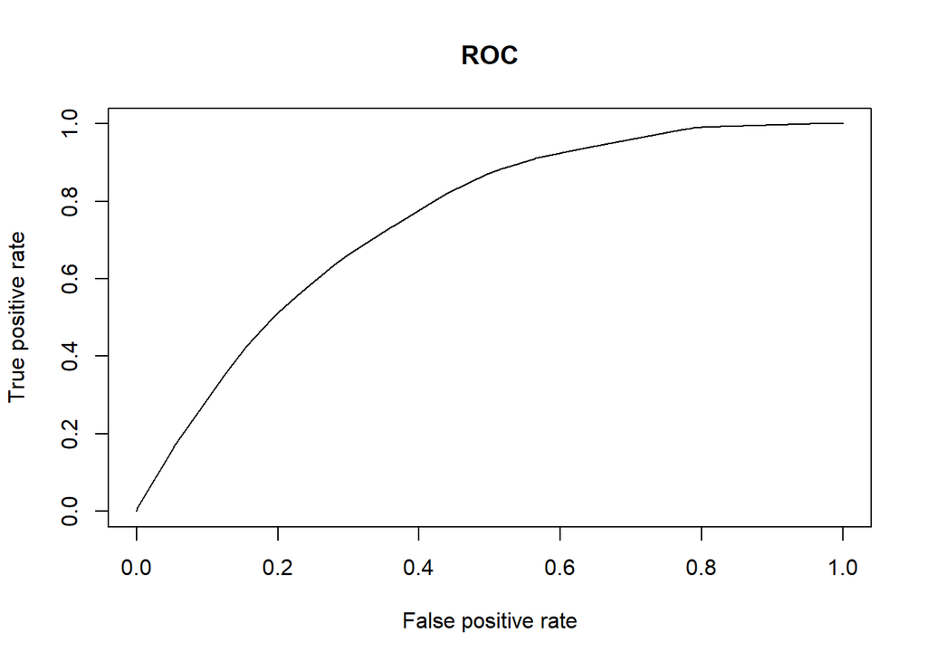

```r
prsa.train$pred <- predict(prsa_model,prsa.train,type='prob')[,2]
prsa.test$pred <- predict(prsa_model,prsa.test,type='prob')[,2]
plot(performance(prediction(prsa.train$pred,
                            prsa.train$bad_air),'tpr', 'fpr'),
     main="ROC")
```

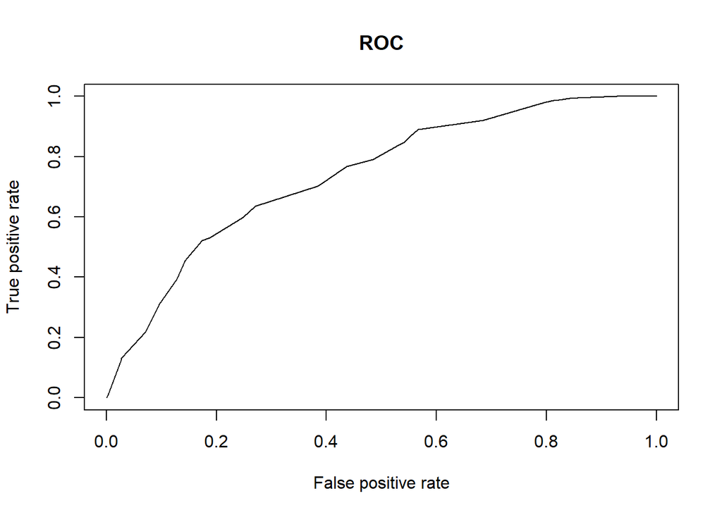

```r
plot(performance(prediction(prsa.test$pred,
                            prsa.test$bad_air),'tpr', 'fpr'),
     main="ROC")
```

```r
calAUC(prsa.train$pred, prsa.train$bad_air)
```

```
## [1] 0.7518051
```

```r
calAUC(prsa.test$pred, prsa.test$bad_air)
```

```
## [1] 0.740323
```

# KNN

### 8

```r
prsa.train <- prsa.train[,-1]
prsa.test <- prsa.test[,-1]

prsa.train2 <-
  cbind(prsa.train, predict(
    dummyVars(~cbwd, data=prsa.train), prsa.train))
prsa.test2 <-
  cbind(prsa.test, predict(
    dummyVars(~cbwd, data=prsa.test), prsa.test))

prsa_train_norm <- sapply(prsa.train2[,c(6:8,10:12,22:25)], minmax_norm)
prsa_test_norm <- sapply(prsa.test2[,c(6:8,10:12,22:25)], minmax_norm)
```

### 9

```r
prsa_train_label <- prsa.train2$bad_air
prsa_test_label <- prsa.test2$bad_air
sqrt(nrow(prsa_train_norm))
```

```
## [1] 181.9231
```

```r
prsa_test_pred <-
  knn(train = prsa_train_norm, test = prsa_test_norm, cl = prsa_train_label,
      k = 180)
mean(prsa_test_label == prsa_test_pred)
```

```
## [1] 0.6775199
```

```r
cmat <- table(prsa_test_label, prsa_test_pred)
prsa_knn_prec <- cmat[2,2] / sum(cmat[,2])
prsa_knn_rec <- cmat[2,2] / sum(cmat[2,])
f1_knn <- f1_measure(prsa_knn_prec, prsa_knn_rec)
prsa_knn_prec
```

```
## [1] 0.6071429
```

```r
prsa_knn_rec
```

```
## [1] 0.9315068
```

```r
f1_knn
```

```
## [1] 0.7351351
```

### 10

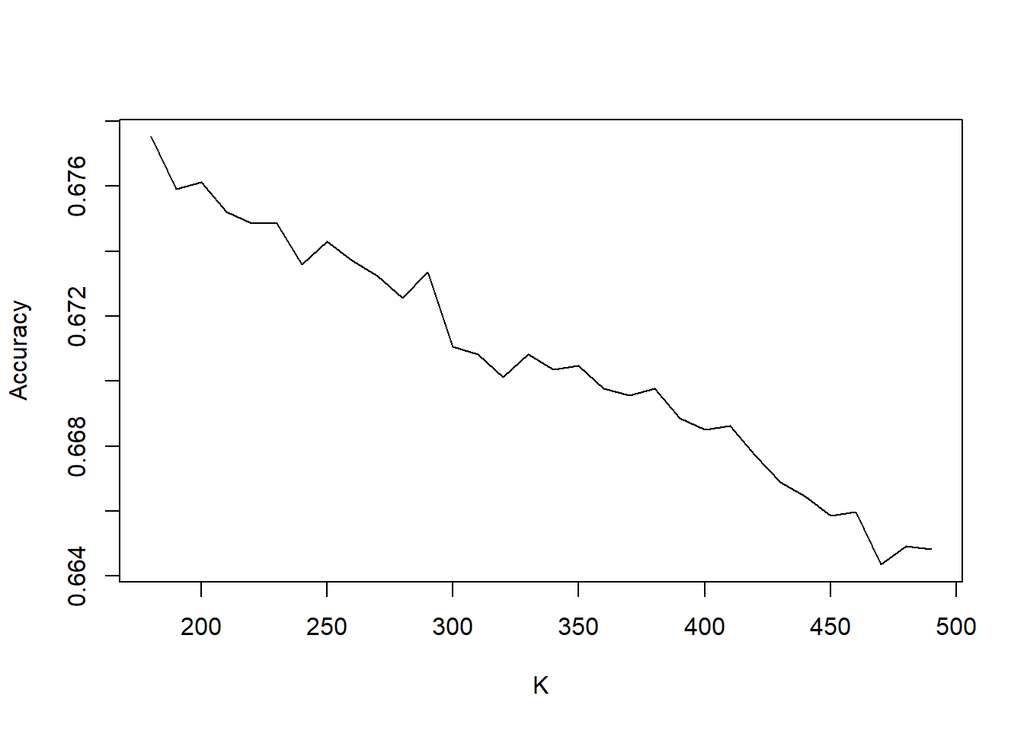

```r
kList <- seq(180, 490, 10)
acc_list <- sapply(kList, getACC)
prec_list <- sapply(kList, getPrec)
rec_list <- sapply(kList, getRecall)
F1_list <- sapply(kList, getF1)
AUC_list <- sapply(kList, getAUC)
plot(x=kList, y=acc_list, xlab="K", ylab="Accuracy", type="l")
```

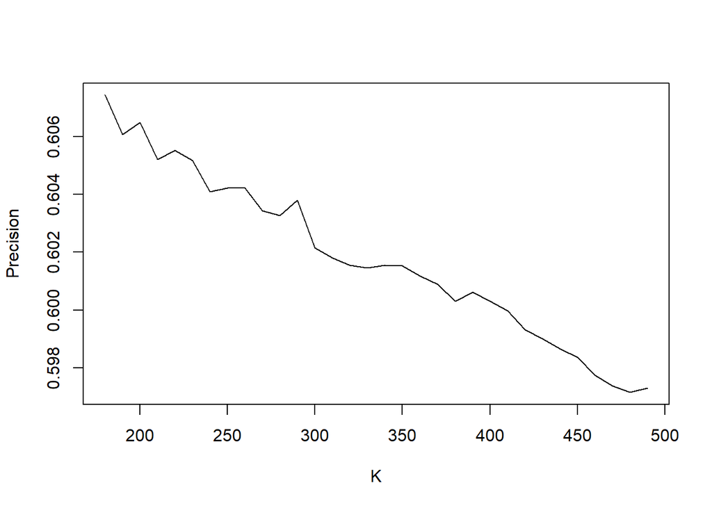

```r
plot(x=kList, y=prec_list, xlab="K", ylab="Precision", type="l")
```

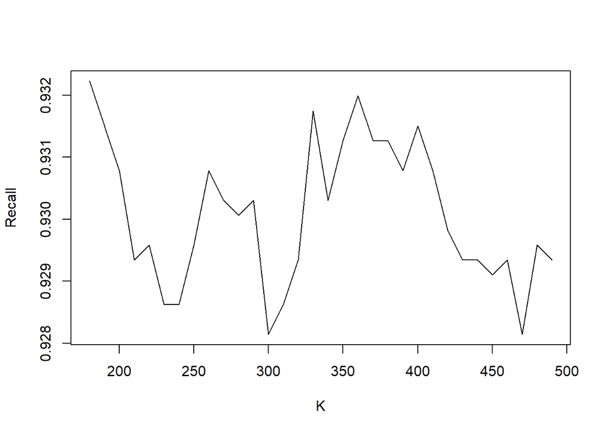

```r
plot(x=kList, y=rec_list, xlab="K", ylab="Recall", type="l")
```

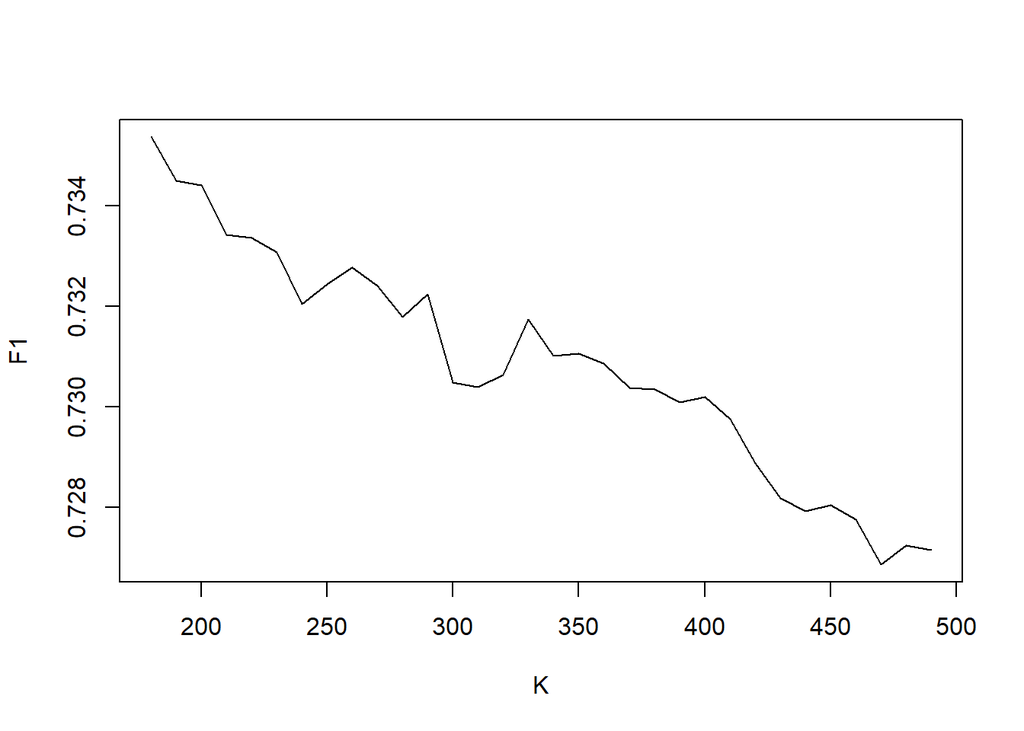

```r
plot(x=kList, y=F1_list, xlab="K", ylab="F1", type="l")
```

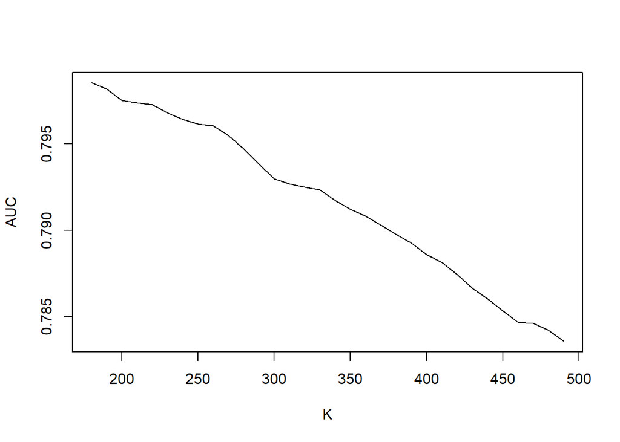

```r
plot(x=kList, y=AUC_list, xlab="K", ylab="AUC", type="l")
```

> > Since this model pay more price to recall than precision, it is important to increase recall rather than precision. You can see from Question 10 that it has highest recall in k=180 and 360. But considering other result such as precision, accuracy, f1, and AUC, you can find out that k=180 has higher precision, accuracy, f1, and AUC than k=360.

### 11

> > Currently, recall value is 0.931. To increase recall on k=180, you can set threshold value and find maximum threshold that makes highest recall value.

```r
prsa_train_label <- prsa.train2$bad_air
prsa_test_label <- prsa.test2$bad_air
```

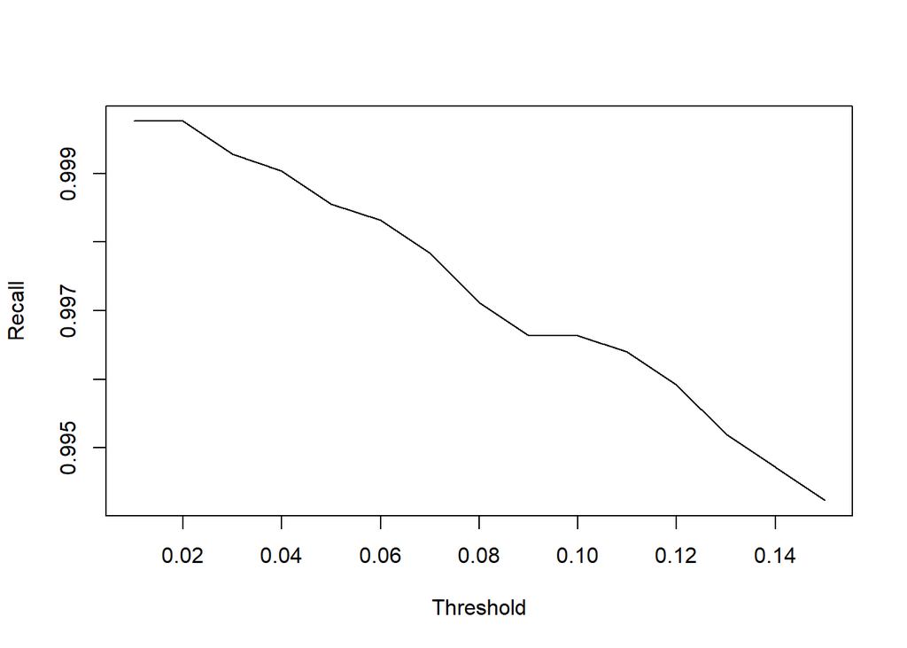

```r
prsa_test_pred <-
  knn(train = prsa_train_norm, test = prsa_test_norm, cl = prsa_train_label,
      k = 180, prob = TRUE)

threshold <- 0.05

thr_seq <- seq(0.01, 0.15, 0.01)

thres_result <- sapply(thr_seq, get_high_thres_recall)
plot(thr_seq, thres_result, xlab="Threshold", ylab="Recall", type="l")
```

> > Recall is highest when threshold is 0.01 or 0.02.